# **COVID 19 Lung Damage Detection using Convolutional Neural Networks and Data Augmentation**

- Below 5 cells of codes is to fetch Kaggle Datasets into Google Colab directly

```python
from google.colab import drive
drive.mount('/content/gdrive')
```

```python
#import os
#os.environ['KAGGLE_CONFIG_DIR'] = "/content/gdrive/My Drive/Kaggle"
# /content/gdrive/My Drive/Kaggle is the path where kaggle.json is present in the Google Drive
```

```python
#changing the working directory
#%cd /content/gdrive/My Drive/Kaggle
#Check the present working directory using pwd command
```

```python
#!kaggle datasets download -d paultimothymooney/chest-xray-pneumonia
```

```python
#unzipping the zip files and deleting the zip files
#!unzip \*.zip  && rm *.zip
```

# **Importing Libraries**

```python
import matplotlib.pyplot as plt
import numpy as np
import seaborn as sns
import keras
import tensorflow as tf
from keras.models import Sequential
from keras.layers import Dense, Conv2D , MaxPool2D , Flatten , Dropout , BatchNormalization
from keras.preprocessing.image import ImageDataGenerator
from tensorflow.keras.models import Sequential
from sklearn.model_selection import train_test_split
from sklearn.metrics import classification_report,confusion_matrix
from keras.callbacks import ReduceLROnPlateau
from keras.models import Model
from tensorflow.keras.preprocessing.image import ImageDataGenerator
from tensorflow.keras.preprocessing import image
from tensorflow.keras.optimizers import RMSprop
import cv2
import os
```

# **Normalization**

```python
train = ImageDataGenerator(rescale=1/255)
val = ImageDataGenerator(rescale=1/255)
test = ImageDataGenerator(rescale=1/255)
```

# **Train,validation,Test Split**

```python
train_dataset = train.flow_from_directory('/content/drive/MyDrive/Kaggle/chest_xray/chest_xray/train',
                                          target_size=(200,200),
                                          batch_size=3,
                                          class_mode='binary') # We are having only 2 output classes in dataset so we are using 'Binary' class mode
val_dataset = val.flow_from_directory('/content/drive/MyDrive/Kaggle/chest_xray/chest_xray/val',
                                          target_size=(200,200),
                                          batch_size=3,
                                          class_mode='binary')
```

```
Found 5216 images belonging to 2 classes.
Found 16 images belonging to 2 classes.
```

```python
test_dataset = test.flow_from_directory('/content/drive/MyDrive/Kaggle/chest_xray/chest_xray/test',
                                          target_size=(200,200),
                                          batch_size=3,
                                          class_mode='binary')
```

```
Found 624 images belonging to 2 classes.
```

- **Changed Categotical classes to numerical**

```python
train_dataset.class_indices
```

```
{'NORMAL': 0, 'PNEUMONIA': 1}
```

```python
train_dataset.classes
```

```
array([0, 0, 0, ..., 1, 1, 1], dtype=int32)
```

```python
train_dataset.class_mode
```

```
'binary'
```

```python
train_dataset.color_mode
```

```
'rgb'
```

```python
val_dataset.class_indices
```

```
{'NORMAL': 0, 'PNEUMONIA': 1}
```

```python
(train_dataset.classes)
```

```
array([0, 0, 0, ..., 1, 1, 1], dtype=int32)
```

```python
len(train_dataset.classes)
```

```
5216
```

```python
img = image.load_img('/content/drive/MyDrive/Kaggle/chest_xray/chest_xray/val/NORMAL/NORMAL2-IM-1427-0001.jpeg')
```

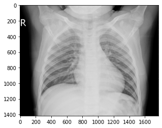

```python
plt.imshow(img)
```

```python
os.listdir('/content/drive/MyDrive/Kaggle/chest_xray/chest_xray/val/NORMAL')
```

```
['NORMAL2-IM-1431-0001.jpeg',
 'NORMAL2-IM-1440-0001.jpeg',
 'NORMAL2-IM-1436-0001.jpeg',
 'NORMAL2-IM-1438-0001.jpeg',
 'NORMAL2-IM-1427-0001.jpeg',
 '.DS_Store',
 'NORMAL2-IM-1430-0001.jpeg',
 'NORMAL2-IM-1442-0001.jpeg',
 'NORMAL2-IM-1437-0001.jpeg']
```

```
X-rays of Normal Person
```

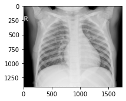

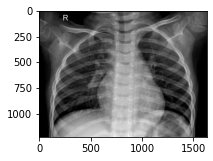

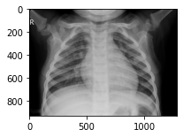

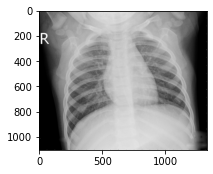

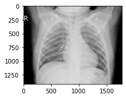

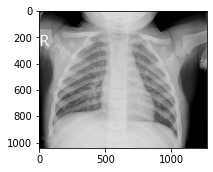

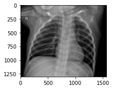

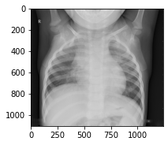

```python
dir_path_normal = '/content/drive/MyDrive/Kaggle/chest_xray/chest_xray/val/NORMAL'
print("X-rays of Normal Person")
for i in os.listdir(dir_path_normal):
  if i != '.DS_Store':
    img=image.load_img(dir_path_normal+'//'+i)
    plt.figure(figsize=(3,3))
    plt.imshow(img)
    plt.show()
    #count +=1
```

```python
dir_path_pneumonia = '/content/drive/MyDrive/Kaggle/chest_xray/chest_xray/val/PNEUMONIA'
os.listdir(dir_path_pneumonia)
```

```
['person1954_bacteria_4886.jpeg',
 'person1951_bacteria_4882.jpeg',
 'person1946_bacteria_4874.jpeg',
 'person1947_bacteria_4876.jpeg',
 '.DS_Store',
 'person1946_bacteria_4875.jpeg',
 'person1949_bacteria_4880.jpeg',
 'person1952_bacteria_4883.jpeg',
 'person1950_bacteria_4881.jpeg']
```

```
X-rays of Pneumonia Person
```

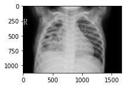

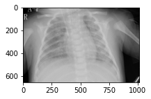

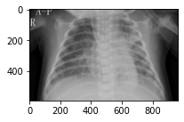

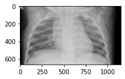

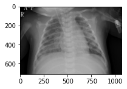

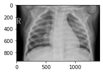

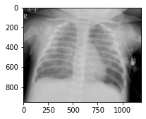

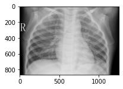

```python
dir_path_pneumonia = '/content/drive/MyDrive/Kaggle/chest_xray/chest_xray/val/PNEUMONIA'
print("X-rays of Pneumonia Person")

for i in os.listdir(dir_path_pneumonia):
  if i != '.DS_Store':
    img=image.load_img(dir_path_pneumonia+'//'+i)
    plt.figure(figsize=(3,3))
    plt.imshow(img)
    plt.show()
    #count +=1
```

# **5. Model Building**

o CNN Model  
o Use Callbacks(ReduceLROnPlateau)  
o Model Fitting

# **CNN Model**

```python
model = tf.keras.models.Sequential([
                                    tf.keras.layers.Conv2D(16,(3,3), activation='relu',input_shape = (200,200,3)),
                                    tf.keras.layers.MaxPool2D(2,2),
                                    tf.keras.layers.Conv2D(32,(3,3), activation='relu'),
                                    tf.keras.layers.MaxPool2D(2,2),
                                    tf.keras.layers.Conv2D(64,(3,3), activation='relu'),
                                    tf.keras.layers.MaxPool2D(2,2),
                                    tf.keras.layers.Flatten(),
                                    tf.keras.layers.Dense(512,activation='relu'),
                                    tf.keras.layers.Dense(1,activation='sigmoid')
])
```

```python
model.compile(loss='binary_crossentropy',
              optimizer=RMSprop(lr=0.001),
              metrics=['accuracy'] )
```

```python
plot=modet_fit=model.fit(train_dataset,validation_data= val_dataset)
```

```python
#evaluating the model for testing data..
test_loss,test_acc=model.evaluate(test_dataset)
```

```python
print("Accuracy of the model is - " , test_acc*100 , "%")
```

```
Accuracy of the model is -  75.96153616905212 %
```

- **Predicting Validation set**

```python
from sklearn.metrics import classification_report, confusion_matrix

val_pred=model.predict(val_dataset)
print(val_pred)
```

```
[[0.27857935]
 [0.15080792]
 [0.813719  ]
 [0.49991062]
 [0.11625698]
 [0.1255088 ]
 [0.85398793]
 [0.25303146]
 [0.01902763]
 [0.95835435]
 [0.97433996]
 [0.785172  ]
 [0.03815746]
 [0.49392205]
 [0.07675053]
 [0.88549244]]
```

```python
val_pred = np.argmax(val_pred, axis=1)
print(val_pred)
```

```
[0 0 0 0 0 0 0 0 0 0 0 0 0 0 0 0]
```

```python
val_pred= model.predict_classes(val_dataset)
val_pred
```

```
array([[0],
       [1],
       [0],
       [0],
       [1],
       [1],
       [0],
       [0],
       [0],
       [1],
       [1],
       [1],
       [0],
       [0],
       [0],
       [0]], dtype=int32)
```

- **Defing a function for visualization**

```python
def graph(plot):
  acc = plot.history['accuracy']
  val_acc = plot.history['val_accuracy']
  loss = plot.history['loss']
  val_loss = plot.history['val_loss']

  plt.figure(figsize=(10,5))
  plt.plot(acc, label='Training accuracy')
  plt.plot(val_acc, label='Validation accuracy')
  plt.plot(loss, label='Training loss')
  plt.plot(val_loss,  label='Validation loss')
  plt.ylabel('accuracy and loss')
  plt.xlabel('epoch')
  plt.title('Training loss & accuracy and validation loss & accuracy')
  plt.legend(loc='best')
  plt.show()
```

```python
def graphacc(plot):
  acc = plot.history['accuracy']
  val_acc = plot.history['val_accuracy']

  plt.figure(figsize=(10,5))
  plt.plot(acc, label='Training accuracy')
  plt.plot(val_acc, label='Validation accuracy')
  plt.ylabel('accuracy')
  plt.xlabel('epoch')
  plt.title('Training & validation : accuracy')
  plt.legend(loc='best')
  plt.show()
```

```python
def graphloss(plot):
  loss = plot.history['loss']
  val_loss = plot.history['val_loss']

  plt.figure(figsize=(10,5))
  plt.plot(loss, label='Training loss')
  plt.plot(val_loss,  label='Validation loss')
  plt.ylabel('loss')
  plt.xlabel('epoch')
  plt.title('Training & validation : loss')
  plt.legend(loc='best')
  plt.show()
```

# **Use Callbacks(ReduceLROnPlateau)**

```python
model = tf.keras.models.Sequential([
                                    tf.keras.layers.Conv2D(16,(3,3), activation='relu',input_shape = (200,200,3)),
                                    tf.keras.layers.MaxPool2D(2,2),
                                    tf.keras.layers.Conv2D(32,(3,3), activation='relu'),
                                    tf.keras.layers.MaxPool2D(2,2),
                                    tf.keras.layers.Conv2D(64,(3,3), activation='relu'),
                                    tf.keras.layers.MaxPool2D(2,2),
                                    tf.keras.layers.Flatten(),
                                    tf.keras.layers.Dense(512,activation='relu'),
                                    tf.keras.layers.Dense(1,activation='sigmoid')
])
```

```python
from keras.callbacks import ReduceLROnPlateau

rlrop = ReduceLROnPlateau()
```

```python
model.compile(loss='binary_crossentropy',
              optimizer=RMSprop(lr=0.001),
              metrics=['accuracy'] )
```

```python
callbacksplot=model.fit(train_dataset,validation_data= val_dataset,epochs=10,callbacks=[rlrop])
```

# **Accuarcy and Loss Visualization**

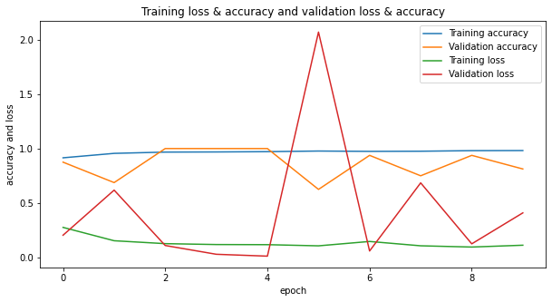

```python
graph(callbacksplot) # calling user defined function for visualization
```

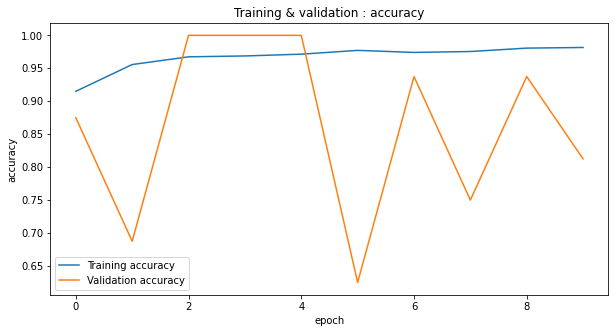

```python
graphacc(callbacksplot) # calling user defined function for visualization
```

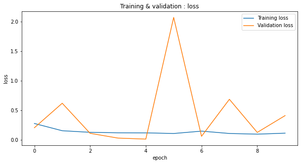

```python
graphloss(callbacksplot) # calling user defined function for visualization
```

- **After Using Early Stops**

```python
model = tf.keras.models.Sequential([
                                    tf.keras.layers.Conv2D(16,(3,3), activation='relu',input_shape = (200,200,3)),
                                    tf.keras.layers.MaxPool2D(2,2),
                                    tf.keras.layers.Conv2D(32,(3,3), activation='relu'),
                                    tf.keras.layers.MaxPool2D(2,2),
                                    tf.keras.layers.Conv2D(64,(3,3), activation='relu'),
                                    tf.keras.layers.MaxPool2D(2,2),
                                    tf.keras.layers.Flatten(),
                                    tf.keras.layers.Dense(512,activation='relu'),
                                    tf.keras.layers.Dense(1,activation='sigmoid')
])
```

```python
model.compile(loss='binary_crossentropy',
              optimizer=RMSprop(lr=0.001),
              metrics=['accuracy'] )
```

```python
my_callbacks=[
              tf.keras.callbacks.ReduceLROnPlateau(),
              tf.keras.callbacks.EarlyStopping()]
```

```python
plotcallback=model.fit(train_dataset,validation_data= val_dataset,epochs=10,callbacks=my_callbacks)
```

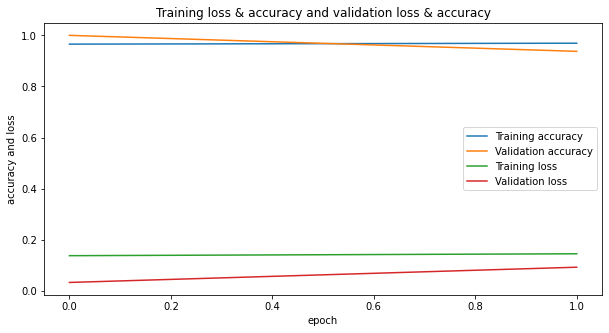

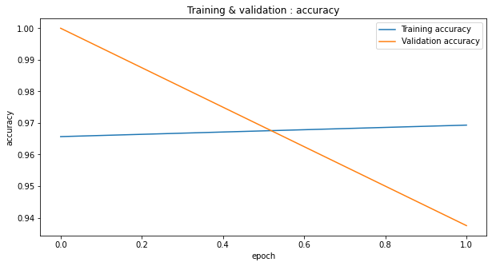

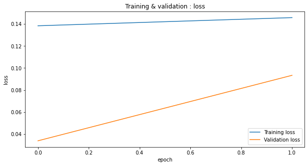

```python
# calling user defined function for visualization
graph(plotcallback)
graphacc(plotcallback)
graphloss(plotcallback)
```

```python
plotcallback1=model.fit(train_dataset,validation_data= val_dataset,epochs=10,callbacks=[tf.keras.callbacks.ReduceLROnPlateau(),
              tf.keras.callbacks.EarlyStopping(patience=10)])
```

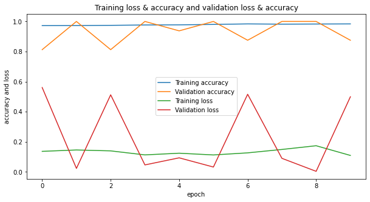

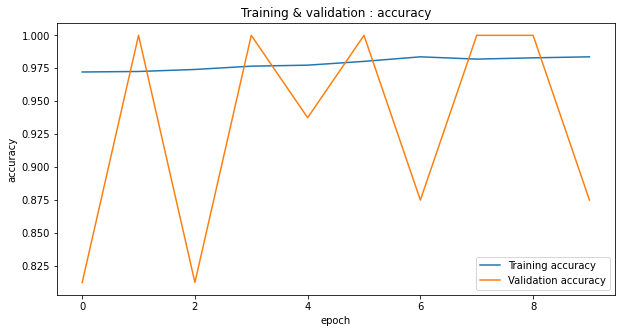

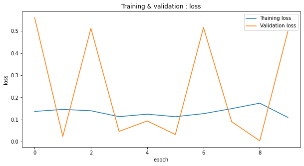

```python
# calling user defined function for visualization
graph(plotcallback1)
graphacc(plotcallback1)
graphloss(plotcallback1)
```

```python
test_loss,test_acc=model.evaluate(test_dataset)
print("Test accuracy:",test_acc)
print("Accuracy of the model on Test Data Set - " , test_acc*100 , "%")
```

```
Test accuracy: 0.7708333134651184
Accuracy of the model on Test Data Set -  77.08333134651184 %
```

From the above experiment I've observed that CNN Model with **RMSprop optimizer, 0.001 learning rate** and **Callbacks with ReduceLROnPlateau** giving Good Accuracy result

# **6. Model Evaluation**

o Confusion Matrix  
o Accuarcy and Loss Visualization

- **Confusion Matrix**

```python
print(confusion_matrix(val_dataset.classes,val_pred))
```

[output not shown]

- **Confusion Matrix Heatmap**

[figure not shown]

```python
sns.heatmap(confusion_matrix(val_dataset.classes,val_pred))
```

- **Classification Report for Validation Data set**

```python
#target_names =[0,1]
print(classification_report(val_dataset.classes,val_pred))
```

[output not shown]

- **Matrix for Test Data set**

```python
#from sklearn.metrics import classification_report, confusion_matrix

test_pred=model.predict(test_dataset)
print(test_pred)
```

```
[[9.9999046e-01]
 [1.6505163e-13]
 [8.1447121e-10]
 ...
 [5.1504292e-15]
 [6.5364592e-15]
 [1.0000000e+00]]
```

```python
test_pred = np.argmax(test_pred, axis=1)
print(test_pred)
```

```
[0 0 0 ... 0 0 0]
```

```python
test_pred= model.predict_classes(test_dataset)
```

- **Classification Report for Test DataSet**

```python
print(classification_report(test_dataset.classes,test_pred))
```

```
              precision    recall  f1-score   support

           0       0.45      0.18      0.26       234
           1       0.64      0.87      0.74       390

    accuracy                           0.61       624
   macro avg       0.55      0.53      0.50       624
weighted avg       0.57      0.61      0.56       624
```

- **Confusion Matrix for Test DataSet**

```python
print(confusion_matrix(test_dataset.classes,test_pred))
```

```
[[ 43 191]
 [ 52 338]]
```

- **Confusion Matrix Heatmap for Test DataSet**

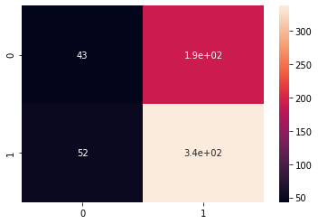

```python
sns.heatmap(confusion_matrix(test_dataset.classes,test_pred),annot=True)
```

# **Challenges to be done:**

1.Apply transfer learning models  
a) VGG16  
B) VGG19  
C) Resnet 50  
D)Resnet 101  
e)Resnet 152

[figure not shown]

# **VGG16**

- Method 1

[figure not shown]

```python
from keras.applications.vgg16 import VGG16
from keras.applications.vgg16 import preprocess_input
```

```python
vgg = VGG16(input_shape=[200,200] + [3] , include_top=False, weights='imagenet')
#vgg.output
```

```python
train = ImageDataGenerator(rescale=1/255)
val = ImageDataGenerator(rescale=1/255)
test = ImageDataGenerator(rescale=1/255)

train_dataset = train.flow_from_directory('/content/drive/MyDrive/Kaggle/chest_xray/chest_xray/train',
                                          target_size=(200,200),
                                          batch_size=3,
                                          class_mode='binary')
val_dataset = val.flow_from_directory('/content/drive/MyDrive/Kaggle/chest_xray/chest_xray/val',
                                          target_size=(200,200),
                                          batch_size=3,
                                          class_mode='binary')
test_dataset = test.flow_from_directory('/content/drive/MyDrive/Kaggle/chest_xray/chest_xray/test',
                                          target_size=(200,200),
                                          batch_size=3,
                                          class_mode='binary')
```

```
Found 5216 images belonging to 2 classes.
Found 16 images belonging to 2 classes.
Found 624 images belonging to 2 classes.
```

```python
IMAGE_SIZE = [200,200]
vgg = VGG16(input_shape=IMAGE_SIZE + [3], weights='imagenet', include_top=False)
#here [3] denotes for RGB images(3 channels)

#don't train existing weights
for layer in vgg.layers:
 layer.trainable = False

x = Flatten()(vgg.output)
prediction = Dense(1, activation='softmax')(x)
model = Model(inputs=vgg.input, outputs=prediction)
model.compile(loss='categorical_crossentropy',
                    optimizer=tf.keras.optimizers.Adam(),
                    metrics=['accuracy'])
model.summary()
```

```
Model: "model_2"
_________________________________________________________________
Layer (type)                 Output Shape              Param #
=================================================================
input_13 (InputLayer)        [(None, 200, 200, 3)]     0
_________________________________________________________________
block1_conv1 (Conv2D)        (None, 200, 200, 64)      1792
_________________________________________________________________
block1_conv2 (Conv2D)        (None, 200, 200, 64)      36928
_________________________________________________________________
block1_pool (MaxPooling2D)   (None, 100, 100, 64)      0
_________________________________________________________________
block2_conv1 (Conv2D)        (None, 100, 100, 128)     73856
_________________________________________________________________
block2_conv2 (Conv2D)        (None, 100, 100, 128)     147584
_________________________________________________________________
block2_pool (MaxPooling2D)   (None, 50, 50, 128)       0
_________________________________________________________________
block3_conv1 (Conv2D)        (None, 50, 50, 256)       295168
_________________________________________________________________
block3_conv2 (Conv2D)        (None, 50, 50, 256)       590080
_________________________________________________________________
block3_conv3 (Conv2D)        (None, 50, 50, 256)       590080
_________________________________________________________________
block3_pool (MaxPooling2D)   (None, 25, 25, 256)       0
_________________________________________________________________
block4_conv1 (Conv2D)        (None, 25, 25, 512)       1180160
_________________________________________________________________
block4_conv2 (Conv2D)        (None, 25, 25, 512)       2359808
_________________________________________________________________
block4_conv3 (Conv2D)        (None, 25, 25, 512)       2359808
_________________________________________________________________
block4_pool (MaxPooling2D)   (None, 12, 12, 512)       0
_________________________________________________________________
block5_conv1 (Conv2D)        (None, 12, 12, 512)       2359808
_________________________________________________________________
block5_conv2 (Conv2D)        (None, 12, 12, 512)       2359808
_________________________________________________________________
block5_conv3 (Conv2D)        (None, 12, 12, 512)       2359808
_________________________________________________________________
block5_pool (MaxPooling2D)   (None, 6, 6, 512)         0
_________________________________________________________________
flatten_14 (Flatten)         (None, 18432)             0
_________________________________________________________________
dense_21 (Dense)             (None, 1)                 18433
=================================================================
Total params: 14,733,121
Trainable params: 18,433
Non-trainable params: 14,714,688
_________________________________________________________________
```

```python
from datetime import datetime
from keras.callbacks import ModelCheckpoint, LearningRateScheduler
from keras.callbacks import ReduceLROnPlateau
lr_reducer = ReduceLROnPlateau(factor=np.sqrt(0.1),
                               cooldown=0,
                               patience=5,
                               min_lr=0.5e-6)
checkpoint = ModelCheckpoint(filepath='mymodel.h5',
                               verbose=1, save_best_only=True)
callbacks = [checkpoint, lr_reducer]
start = datetime.now()
history = model.fit_generator(train_dataset,
                    validation_data = val_dataset)
duration = datetime.now() - start
print("Training completed in time: ", duration)
```

```
Training completed in time:  0:43:01.945325
```

```python
test_loss,test_acc=model.evaluate(test_dataset)

print("Accuracy of the model is - " , test_acc*100 , "%")
```

```
Accuracy of the model is -  62.5 %
```

```python
test_loss,test_acc=model.evaluate(test_dataset)

print("Accuracy of the model is - " , test_acc*100 , "%")
```

```
Accuracy of the model is -  62.5 %
```

# **VGG16**

- Method 2

```python
train = ImageDataGenerator(rescale=1/255)
val = ImageDataGenerator(rescale=1/255)
test = ImageDataGenerator(rescale=1/255)

#TLM: Transfer learning Models
train_dataset_TLM = train.flow_from_directory('/content/drive/MyDrive/Kaggle/chest_xray/chest_xray/train',
                                          target_size=(224,224),
                                          #batch_size=3,
                                          class_mode='binary')
val_dataset_TLM = val.flow_from_directory('/content/drive/MyDrive/Kaggle/chest_xray/chest_xray/val',
                                          target_size=(224,224),
                                          #batch_size=3,
                                          class_mode='binary')
test_dataset_TLM = test.flow_from_directory('/content/drive/MyDrive/Kaggle/chest_xray/chest_xray/test',
                                          target_size=(224,224),
                                          #batch_size=3,
                                          class_mode='binary')
```

```
Found 5216 images belonging to 2 classes.
Found 16 images belonging to 2 classes.
Found 624 images belonging to 2 classes.
```

```python
VGG = keras.applications.vgg16.VGG16(input_shape=(224,224,3), include_top=False, weights='imagenet')
VGG.trainable=False
```

```python
VGG.summary()
```

```
Model: "vgg16"
_________________________________________________________________
Layer (type)                 Output Shape              Param #
=================================================================
input_17 (InputLayer)        [(None, 224, 224, 3)]     0
_________________________________________________________________
block1_conv1 (Conv2D)        (None, 224, 224, 64)      1792
_________________________________________________________________
block1_conv2 (Conv2D)        (None, 224, 224, 64)      36928
_________________________________________________________________
block1_pool (MaxPooling2D)   (None, 112, 112, 64)      0
_________________________________________________________________
block2_conv1 (Conv2D)        (None, 112, 112, 128)     73856
_________________________________________________________________
block2_conv2 (Conv2D)        (None, 112, 112, 128)     147584
_________________________________________________________________
block2_pool (MaxPooling2D)   (None, 56, 56, 128)       0
_________________________________________________________________
block3_conv1 (Conv2D)        (None, 56, 56, 256)       295168
_________________________________________________________________
block3_conv2 (Conv2D)        (None, 56, 56, 256)       590080
_________________________________________________________________
block3_conv3 (Conv2D)        (None, 56, 56, 256)       590080
_________________________________________________________________
block3_pool (MaxPooling2D)   (None, 28, 28, 256)       0
_________________________________________________________________
block4_conv1 (Conv2D)        (None, 28, 28, 512)       1180160
_________________________________________________________________
block4_conv2 (Conv2D)        (None, 28, 28, 512)       2359808
_________________________________________________________________
block4_conv3 (Conv2D)        (None, 28, 28, 512)       2359808
_________________________________________________________________
block4_pool (MaxPooling2D)   (None, 14, 14, 512)       0
_________________________________________________________________
block5_conv1 (Conv2D)        (None, 14, 14, 512)       2359808
_________________________________________________________________
block5_conv2 (Conv2D)        (None, 14, 14, 512)       2359808
_________________________________________________________________
block5_conv3 (Conv2D)        (None, 14, 14, 512)       2359808
_________________________________________________________________
block5_pool (MaxPooling2D)   (None, 7, 7, 512)         0
=================================================================
Total params: 14,714,688
Trainable params: 0
Non-trainable params: 14,714,688
_________________________________________________________________
```

```python
model= keras.Sequential([
                         VGG,
                         keras.layers.Flatten(),
                         keras.layers.Dense(units=256,activation='relu'),
                         keras.layers.Dense(units=256,activation="relu"),
                         keras.layers.Dense(units=1,activation="sigmoid")
])
```

```python
model.summary()
```

```
Model: "sequential_13"
_________________________________________________________________
Layer (type)                 Output Shape              Param #
=================================================================
vgg16 (Functional)           (None, 7, 7, 512)         14714688
_________________________________________________________________
flatten_15 (Flatten)         (None, 25088)             0
_________________________________________________________________
dense_25 (Dense)             (None, 256)               6422784
_________________________________________________________________
dense_26 (Dense)             (None, 256)               65792
_________________________________________________________________
dense_27 (Dense)             (None, 1)                 257
=================================================================
Total params: 21,203,521
Trainable params: 6,488,833
Non-trainable params: 14,714,688
_________________________________________________________________
```

```python
model.compile(loss='binary_crossentropy',
              optimizer=RMSprop(lr=0.001),
              metrics=['accuracy'] )
```

```python
model.summary()
```

```
Model: "sequential_13"
_________________________________________________________________
Layer (type)                 Output Shape              Param #
=================================================================
vgg16 (Functional)           (None, 7, 7, 512)         14714688
_________________________________________________________________
flatten_15 (Flatten)         (None, 25088)             0
_________________________________________________________________
dense_25 (Dense)             (None, 256)               6422784
_________________________________________________________________
dense_26 (Dense)             (None, 256)               65792
_________________________________________________________________
dense_27 (Dense)             (None, 1)                 257
=================================================================
Total params: 21,203,521
Trainable params: 6,488,833
Non-trainable params: 14,714,688
_________________________________________________________________
```

```python
#epoch 10
hist=model.fit_generator(generator=train_dataset_TLM,validation_data= val_dataset_TLM,epochs=10)
model.save('vggclf.h5')
```